# A story in the numbers

Tabitha Peter

Sept. 12, 2026

One of the greatest ironies of contemporary American life lies in the contrast between the tremendous degree to which mathematical principles affect the average person’s daily life and the tremendous degree of the average person’s aversion to math itself.

This week has brought much discussion about the newly released [PISA test scores](https://nces.ed.gov/surveys/pisa/pisa2025/index.asp#/). The scores are not flattering for the United States, particularly for math. Math and its place in American society is a theme I think about almost daily, as it has profoundly shaped my life experiences as a statistician. Reading about the PISA scores, I thought back to my experiences as an ACT tutor. I was a math major in my undergraduate program, and in the summers of 2019 and 2020 I worked at the tutoring business in my hometown. I taught students preparing for the math section of the ACT exams. These high school students represented a wide cross-section of demographic features: I had students from private, public, and parochial schools. Some lived in my urbanized hometown of about 65,000 residents – others drove in from the nearby rural communities. The ACT scores of my students ranged from 15 - 32. Yet amid the diversity of this cross-section of students, the single most common feature among them was their aversion to math. Some were afraid of math, others expressed dislike of learning math, and many were well below the benchmarks for a high school level of mathematcial understanding.

Consider this example from one of my former students - a boy in his late teens, sporting a cookie-duster mustache, his unruly hair tucked into a baseball cap. His main hobby was fishing, as evidenced by his fishing shirt and the logo on his hat. As we worked on ACT math problems together, he struggled to comprehend the word problems. One major barrier in his comprehension was that he did not recognize the mathematical meanings of quantitative language; for example, he needed to learn that ‘per’ means ‘for each’, typically signaling multiplication or division is required. He also needed to learn how to talk about what he was doing on his calculator. For instance, he talked about ‘plussing’ and ‘minusing’ instead of ‘adding’ and ‘subtracting’. Language always indicates thinking, and so such vocabulary misuse was revealing of the student’s foggy understanding. Another challenge for my student was that he had not been taught to draw sketches to help visualize problems, making it more difficult for him to structure the pieces of information in a multi-step word problem. This particular student and his struggles typify what I observed in many others who struggled with math.

But that word: struggle. It seemed that for some students the central challenge in math was their inability to struggle. Several of my students were unable to persist through a multi-step problem. Instead of pivoting to an alternative approach if their first attempt wasn’t leading in a logical direction, these students would give up and say something like, “This is a hard one. I’m just not good at math.” Indeed, it was common for my students to tell me before the lesson began that “math is my worst subject”, or “I’m just not a math person.”

These attitudes towards math were evident in the way students interacted with math questions in the ACT. Like the boy I described earlier, many of my students were unable to comprehend the meaning of quantitative key words/phrases like “per”, “in addition to”, “equivalent”, etc. And my students often had small vocabularies when it came to quantitative concepts: intead of adding and subtracting, they were ‘plussing’ and ‘minusing’. Instead of ‘sphere’, they used words like ‘ball’. As I watched them struggle through ACT practice problems in math, I could not help but wonder: if these students cannot solve multi-step math questions for an exam, how will they create balanced budgets as adults? How will they finance their homes, or make measurements for home repairs, or scale proportions in recipes, or understand health statistics?

# What is numeracy?

As someone who has been trained to think mathematically, tutoring ACT students became more than simply a summer job – these experiences gave me poignant examples of how people in the United States think about math. My students’ fears and disklikes of math continue to be echoed by most of the other Americans in my daily life. Whenever I introduce myself and somone finds out I work as a statistician, the reactions I typically get are “oh, you’re one of *those* math people” or “statistics – that was the class I hated most in college.” If I am sharing a meal in a restaurant with other Americans, I am often called upon to calculate the tip and cost per person because I am the designated *math person*.

These anecdotal observations are reflective of national data about **numeracy**. The National Center for Education Statistics (NCES) defines numeracy as the skills for “accessing, using, and reasoning critically with mathematical content, information and ideas represented in multiple ways in order to engage in and manage the mathematical demands of a range of situations in adult life.” NCES conducts research on numeracy in the United States, and the [2023 Survey of Adult Skills (PIAAC Cycle 2)](https://nces.ed.gov/pubs2020/2020025/index.asp) indicates that about 30% of American adults have a low level of *numeracy*. At a street level, multi-step problem solving looks like designing a household budget or interpreting statistics relevant to a recent medical diagnosis.

To further illustrate what numeracy is, consider these problems from the math section of the [HiSET exam](https://hiset.org/) practice questions:

1. “You are a pharmacy technician. You need to prepare a 0.85-gram dose of a liquid antibiotic. The medicine is concentrated at 250 milligrams of antibiotic per 5 milliliters of liquid. How many milliliters should you pour into a prescription bottle?”
2. “You work in a machine design department and need to specify the diameter of a pin that slides back and forth through a hole. The hole diameter is specified as 0.500 inch with a tolerance of 0.010 inch. The maximum pin diameter must be 0.002 inch smaller than the minimum hole diameter. If the pin diameter has a tolerance of 0.010 inch, what diameter, in inches, should you specify for the pin?”
3. “You are a mechanic who is measuring the valve clearance on a motorcycle engine. The current clearance for one of the valves is 0.30 millimeter (mm). The clearance should be at least 0.18 mm and no more than 0.22 mm. The valve clearance is set by using a spacer that reduces the distance between the cam and the valve by the size of the spacer. Spacers are available in 0.04 mm increments, and the spacer currently in the motorcycle engine is 2.84 mm. What size spacer, in millimeters, should you use to achieve a correct valve clearance?”

Readers are invited to consider these questions, and whether they would be confident in knowing where to begin to derive an answer. These questions (from among the more challenging math problems on the exam) are written to test an older teenaged student’s skills in multi-step problem solving. Solving these problems requiring a solid foundation in numeracy.

Speaking of tests, there is substantive test data from the [National Assessment of Educational Progress (NAEP)](https://www.nagb.gov/powered-by-naep/the-2024-nations-report-card.html) providing further evidence that the United States has a numeracy problem. The NAEP reports are based on exams taken by 4th, 8th, and 12th graders across the country. These exams are sometimes called the ‘nation’s report card’, and this report card is published about every two years. Across all three grade levels (4th, 8th, and 12th), the NAEP reports on students’ performance by categorizing students’ achievement levels as Basic, Proficient, or Advanced. [Results from the math sections](https://www.nagb.gov/naep/mathematics.html) from 2024 are showing declines, as has been noted in past years. These data indicate that about 33% of 12th graders are considered academically ready for entry-level college math coursework, meaning that approximately two-thirds of our nation’s high school seniors are not meeting benchmarks in math. Moreover, the 2024 average 12th grade math score is down 3 points from 2019 and is the lowest score ever reported for 12th grade. Forty-five percent of students are working **below** the NAEP Basic achievement level – the highest percentage ever recorded at that level. [One of the NAEP’s publications](https://www.nagb.gov/powered-by-naep/the-2024-nations-report-card/top-5-takeaways-from-12-grade-naep-math-reading-results.html) described these results this way: “nearly half of [high school] seniors likely cannot apply their knowledge of percentages to solve a real-world problem.” The adult who is not able to apply knowledge of percentages to solve problems will not be able to understand the promotional sales at their grocery store, or the percentages in a pamphlet from their healthcare provider, or the percentages presented in the news surrounding our mid-term elections. Life with low numeracy comes at a real cost.

# Numeracy in a world driven by statistics

Of all the math Americans encounter day to day, statistics in particular affects daily life for the contemporary American adult. Advertisements, medical information, news articles, the over-under for a particular sports game or event – these are all ways that Americans encounter statistics in the wild. Not only are Americans encountering statistics, but they are participating in statistics by providing data. Search engines, social media platforms, and AI models are all built by creating algorithms that curate results for a particular user or prompt. For example, these algorithms are good at predicting products I might like because they have been built using data from many other American women my age as well as my search/purchase histories. American adults are both tacitly providing all the raw material from which algorithms are built and directly being acted upon by those very algorthims.

The preceeding paragraph uses three words that are worth defining: data, algorithm, and statistics. Let me offer my own brief, nontechnical definitions:

- **Data**: Information that is structured so as to make it possible to detect patterns. ‘Data’ is often a plural word, implying that the information is gathered across multiple *data points*.
- **Algorithm**: A method or strategy for solving an analytical problem. In the context of data analysis, an algorithm is often a method for detecting patterns from data.
- **Statistics**: The study of using data and algorithms to evaluate evidence in the face of uncertainty. Statistics usually has one of two goals: (1) to use evidence from data to identify a pattern (this is *inference*), or (2) to make a forecast about the future based on data available in the present (this is *prediction*).

In these definitions, I want to point out that statistics is dependent on data and algorithms. This dependence explains why statistics is becoming increasingly important for our present time; the digitization of information and the dramatic improvements in computer technology have made data grow abundant and algorithms grow powerful. Statistics are driving much - if not most - of the decision-making in contemporary America. Understanding and interpreting statistics requires strong numeracy skills, so the fact that many Americans have low numeracy skills should give us pause for concern. Those who are unequipped with strong numeracy skills will be unable to understand or have agency in the data and algorithms that shape their lives. Decisions will continue to be made by those who have a strong command of statistics – i.e., those who are numerate as well as literate.

# A fallacy

Movies and film are strong indications of the stories shaping a culture, and so examining how American film portrays math can tell us a great deal about our culture’s view of math. Notice how few stories in American TV shows, movies, and books prominently feature people doing quantitative work. We have countless drama series about doctors, lawyers, and people working in large corporations, but no such series about statisticians or engineers. There is the character Sheldon, the physicist from the show “Big Bang Theory” - but he is a fun character to make us laugh, not someone most people would encourage their child to become more like.

Moreover, the portraits we have from movies of people excelling in math are of rugged individuals with extraordinary talent: Good Will Hunting (1997), A Beautiful Mind (2001), and The Imitation Game (2014) are all examples of such stories. In each one of these films, the focus is a mathematical genius working independently. This is misleading. In real life, working in the mathematical sciences as an isolated genius is the exception rather than the rule. Yes, there are generational talents in math, as there are in all fields – but most real quantitative work is done by ordinary, well-trained people working in teams.

My own job is illustrative of this kind of mathematical teamwork. I work as a clinicial trials statistician in a large pharmaceutical company. Pharmaceutical companies that sponsor clinical trials need statisticians at every stage of carrying out a clinical trial. Determining how many patients to recruit, how to define the trial outcomes as measurable quantities, and choosing the methods by which to compare those quantities are all questions that rely on statistics. Teams of statisticians come together to weigh out these decisions, consulting with one another and validating one another’s calculations. No table or graph is published until multiple statisticians have reviewed it and verified its accuracy. Beyond our work together as statisticians, we are also embedded members of cross-functional teams that include medical doctors and other clinical professionals. Group meetings account for a large proportion of our work responsibilities. Unlike the movies, our quantitative work is highly relational - we work in teams.

The explanation for why most jobs in the quantitative sciences require teamwork is not primarly one of efficiency. Working with a group to come to consenus is often a challenge that requires much more time than a single scientist making a decision. Rather than for efficiency, teamwork in the quantiative sciences is a norm because it acts as a safeguard for high-stakes decisions. A single statistician may make an inadvertent error in a calculation that will determine the medical decisions for a group of patients; working on a team ensures this error is caught and addressed before clinicial decisions are made based on that calculation. In our contemporary work, most high-stakes decisions require mathematical analysis - and when stakes are high, teamwork is a safeguard against errors. This is true in other fields outside pharmaceuticals, like business analytics and supply chain management. Making pivotal decisions based on data and algorithms is essential for a digital, information-based economy. The decision makers in this economy will be teams of people trained to have a high capacity for quantitative analysis.

# A fallback plan

|  | **N = 3,119,855**<sup>1</sup> |
| --- | --- |
| Job Category (Using Gov't Codes (SOC)) |  |
| Software Developers | 680,373 (22%) |
| Software Developers, Applications | 330,892 (11%) |
| Computer Systems Engineers/Architects | 137,154 (4.4%) |
| Computer Systems Analysts | 132,164 (4.2%) |
| Information Technology Project Managers | 97,356 (3.1%) |
| Computer and Information Systems Managers | 69,564 (2.2%) |
| Software Quality Assurance Analysts and Testers | 68,174 (2.2%) |
| Computer Programmers | 65,642 (2.1%) |
| Software Developers, Systems Software | 64,538 (2.1%) |
| Business Intelligence Analysts | 63,921 (2.0%) |
| Data Scientists | 63,795 (2.0%) |
| Mechanical Engineers | 53,697 (1.7%) |
| Operations Research Analysts | 49,443 (1.6%) |
| Accountants and Auditors | 47,582 (1.5%) |
| Electronics Engineers, Except Computer | 46,265 (1.5%) |
| Electrical Engineers | 39,547 (1.3%) |
| Database Administrators | 38,371 (1.2%) |
| Management Analysts | 36,523 (1.2%) |
| Financial and Investment Analysts | 29,765 (1.0%) |
| Statisticians | 29,676 (1.0%) |
| Industrial Engineers | 29,406 (0.9%) |
| Network and Computer Systems Administrators | 27,753 (0.9%) |
| Medical Scientists, Except Epidemiologists | 27,279 (0.9%) |
| Civil Engineers | 26,239 (0.8%) |
| Software Quality Assurance Engineers and Testers | 25,697 (0.8%) |
| All Other Categories | 839,039 (27%) |

<sup>1</sup> n (%)

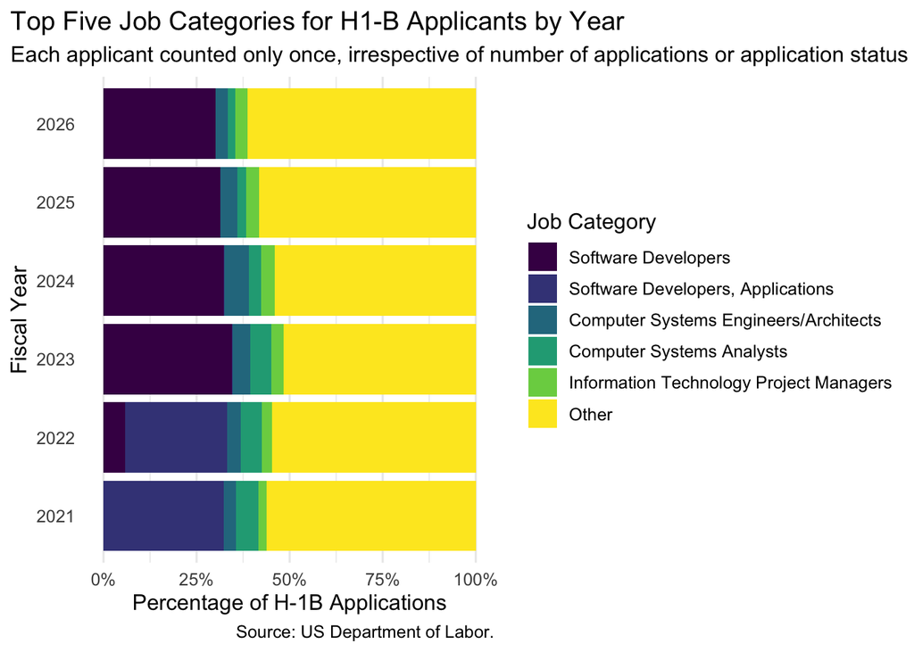

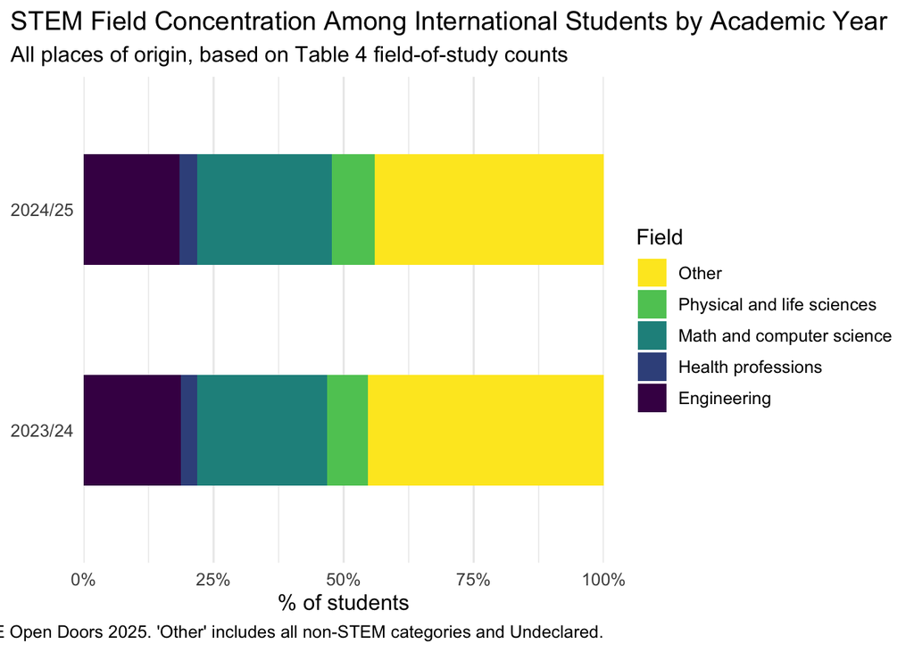

When I look at these data, I do not see an immigration problem or a policy issue. What I do see is evidence that American students are not prepared for degree programs or jobs that require high degrees of numeracy. Instead of addressing the low numeracy skills among students and adults in the United States, the national fallback plan has been to outsource jobs requiring high numeracy skills to international workers. This does not mean that skilled immigration takes away American jobs; it means that we have a situation where skilled immigration is necessary because most Americans are not able to do these jobs.

Economist Daron Acemoglu spoke to this issue in a [recent interview with Tyler Cowen](https://conversationswithtyler.com/episodes/daron-acemoglu-2/). Dr. Acemoglu voiced that although he himself arrived in the United States with an H1-B visa, he is concerned that the H1-B has become a way for American corporations to circumvent the problem that Americans are not prepared for the workforce. Acemoglu hypothesized that American corporations are not pressuring the education system to produce workers that meet business needs, because these corporations can hire skilled immigrants to do the work. While Acemoglu and Cowen did not mention numeracy explicitly, the importance of quantitative skills was implicit in the kinds of jobs/coporations about which they were speaking. As part of the conversation, Cowen referenced [one of Acemoglu’s Op-Ed pieces](https://www.project-syndicate.org/commentary/us-skilled-immigration-policy-trump-h1b-visa-debate-by-daron-acemoglu-2025-01); in that piece, Acemoglu points out that the scarcity of engineers is the single greatest limiting factor in Sillicon Valley. Think about what that means.

The US has yet to address its internal issues with people not learning math, and this cannot be changed overnight with dramatic policy change. Financially and polically pressuring companies to hire American-born workers does not create Americans with greater numeracy *ex nihilo*. The path to training more numerate Americans for the demands of a digital world is a complex problem that will require a sustained effort from families, educators, and corporations.

# The way forward

So how would the US address the roots of its internal issues with mathematical literacy? It is an oversimplification to point to the education system alone – the problem of weak numeracy is deeper than math test scores. Thinking back to what I observed in my ACT students, we must work to address and reverse negative attitude towards math. What American students – and their parents and teachers – must come to recognize is the reality that math is a basic life skill, just like reading. No one would ever openly designate themselves as unable to read – that is culturally unacceptable, maybe even taboo in some circles. Yet it remains widely acceptable for an American student or adult to make statements like “I just can’t do math”. It is at this attitude level that some ..real change has to happen. Both educators and families need to assume some agency in promoting this kind of cultural change – we must show American students of all ages the beauty and utility of math, in that order. Unless students come to see that math is connected to art and music, they will think it is only a brute tool to be used for when life presents challenging problems. They many even begin to think math is a job for someone else to do.

For those of us who do not have direct contact with students, we still have a part to play in promoting numeracy – and it starts in our language. It is revealing that the way most of us speak about math in the common vernacular is *problematic*: we speak of math *problems*, rather than about math opportunities. We seldom make connections between math and visual art, music, and the amazing shapes of the flowers we see around us. These connections are vital for growing numeracy - we have to recognize that math is about patterns, order, and shapes – not about solving for $x$ for a test.

This way of presenting the beauty of math is not an unrealistic, pie-in-the-sky goal. I know it can be done, because my tenth grade geometry teacher did it. Mrs. K taught for at least thirty years in my local public school system. She taught geometry with art projects; I remember doing oragami (paper folding) to learn about different kinds of angles and shapes. I also remember a final project in which we used paints and a sheet of plastic to make a stained-glass style wall hanging with geometric patterns. Mrs. K sometimes came in to our early morning class in a rush – she was not a morning person – and her desk was always piled high with all kinds of papers. Yet she never lost sight of her mission, and she cultivated the skill of making math engaging. Her desk had a poster taped to the front that said, “What do teachers make? A difference!” And that she did. I came to her class unsure of whether I could be good at math, and I left her class with a lasting fascination of how beautiful math is.

When people ask if I have always been a ‘math whiz’, I give them the honest answer: no. Math did not come easily to me; it took years of training and instruction. I even needed to repeat one of my courses in graduate school. Aquiring a high degree of numeracy is not natural or effortless to most; it is a daily discipline, a process of training the mind to think in a logical, analytical way. Thinking mathematically requires mastering one’s own mind, when the human default is to run off of pure emotion.

Not everyone’s process of becoming numerate will look like mine. Yet my own life does show that numeracy is teachable. Americans who can think mathematically can come from anywhere in the country where there are well-trained and dedicated teachers, invested parents, and scholarships/recruitment programs with strategic involvement from both the public and private sectors. Rooting out our culture’s deep-seated aversion to math and putting down new roots for teaching numeracy will require the combined efforts of educators, families, government initiatives, and corporations. Such change will not be easy or fast – but the realities of the labor market are such that we cannot afford not to make these efforts. Even beyond the labor market, increasing numeracy will increase clear thinking and sound reasoning – two rare items which may be the hottest commodities on any market.